# Внешний курс

Выполнение внешнего курса. Основы Linux. Раздел 3

Титков Ярослав Максимович

Российский университет дружбы народов, Москва, Россия

## Задание

Выполнить задания, представленные в третьем разделе курса.

## Скриншот 1

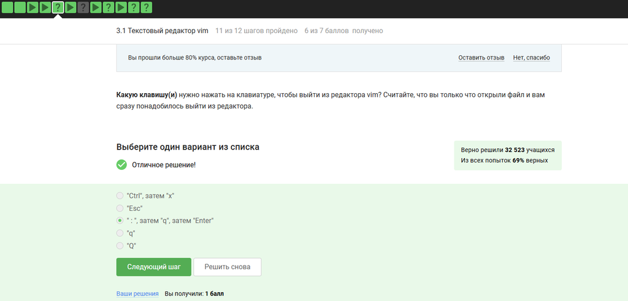

Выбран вариант :q + Enter, так как это стандартная команда для выхода из Vim без сохранения.

## Скриншот 2

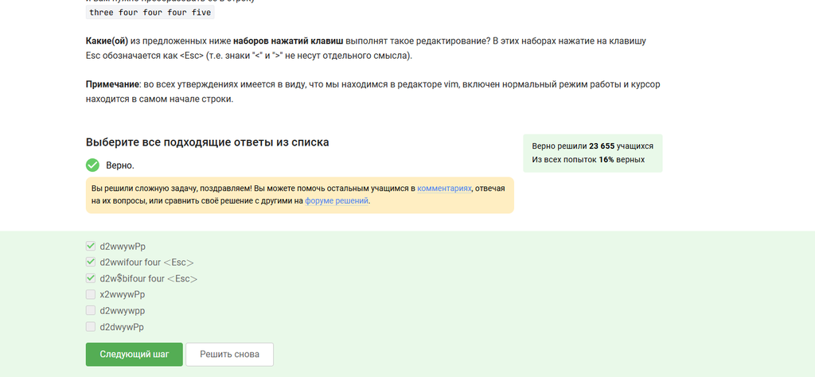

## Скриншот 3

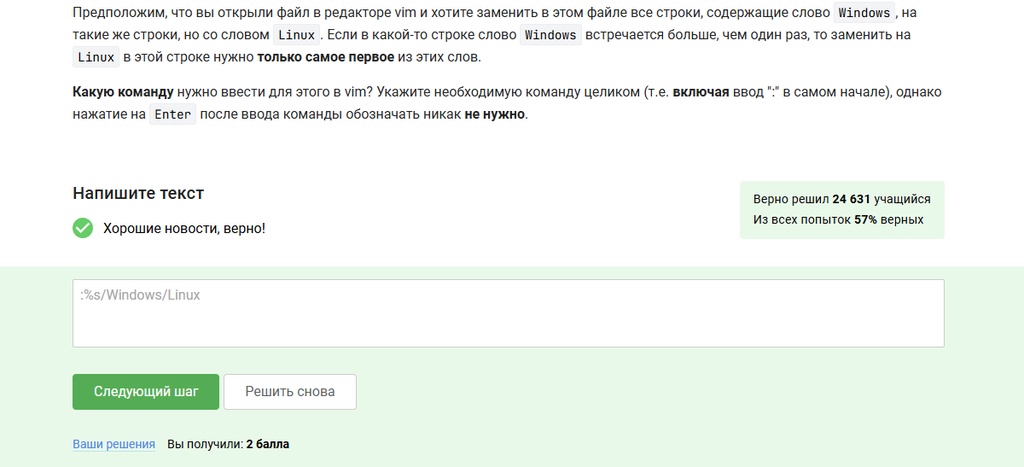

Выбрана команда :%s/Windows/Linux, так как она заменяет первое вхождение “Windows” на “Linux” во всём файле.

## Скриншот 4

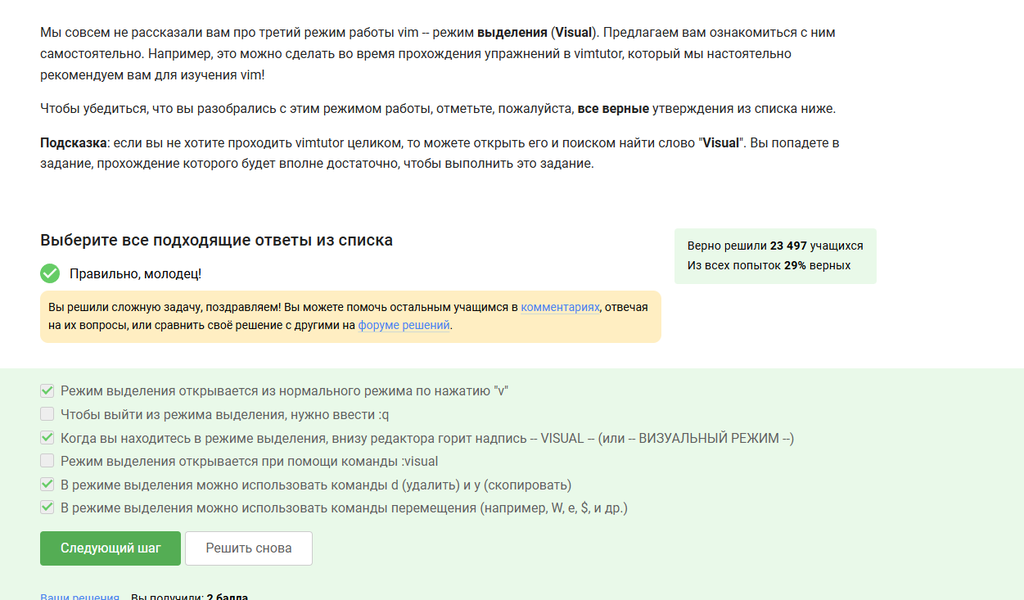

Выбраны верные утверждения о режиме выделения в Vim (открывается на v, поддерживает команды d и y).

## Скриншот 5

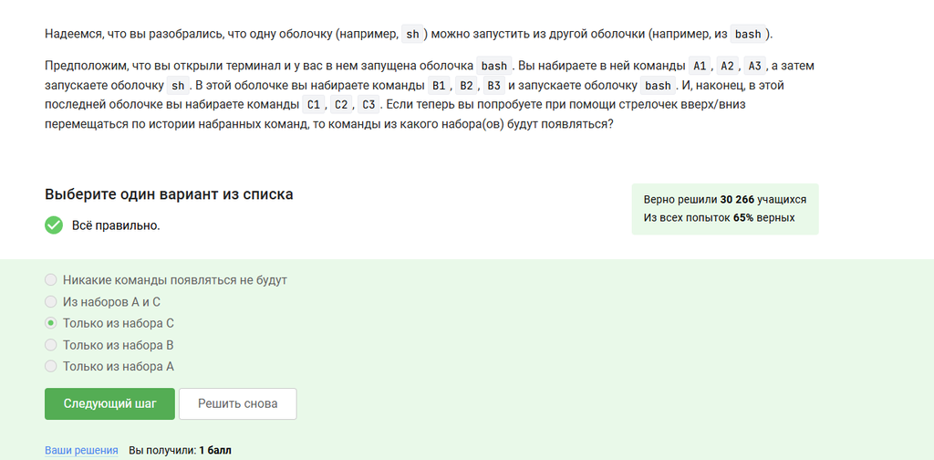

Выбран вариант “Только из набора C”, так как история команд вложенных оболочек не сохраняется в родительской.

## Скриншот 6

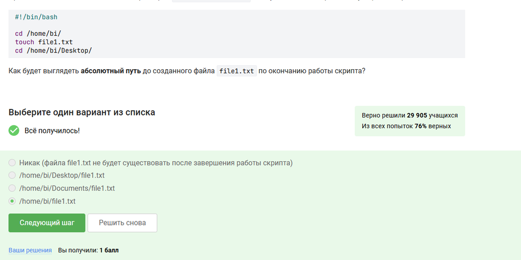

Выбран путь /home/bi/file1.txt, так как файл создаётся в этой директории до смены пути.

## Скриншот 7

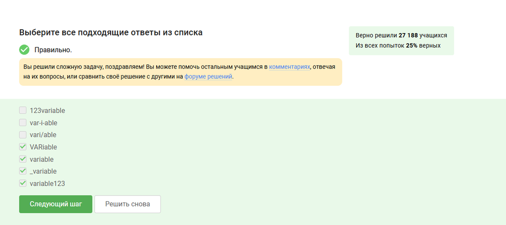

Выбраны корректные имена переменных (начинаются с буквы/подчёркивания, без спецсимволов).

## Скриншот 8

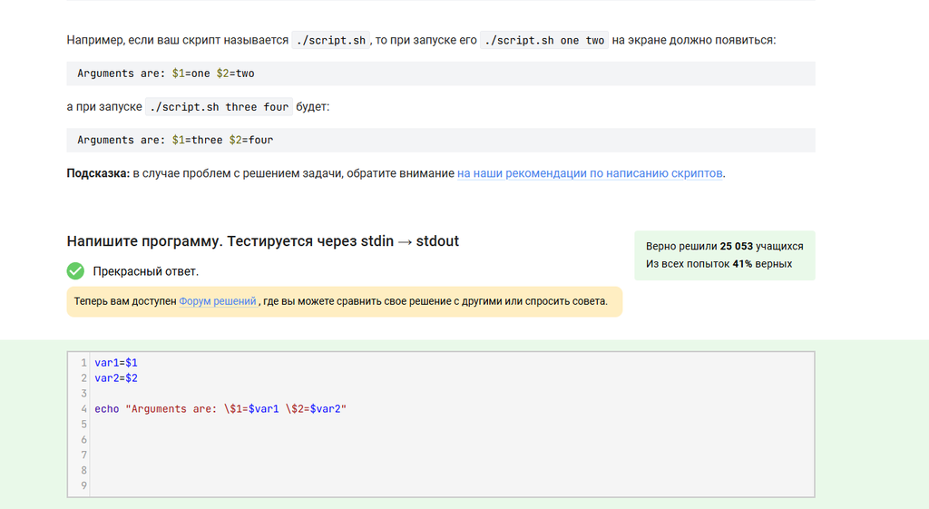

Выбран вариант с выводом аргументов скрипта ($1 и $2), так как задача требует отображать переданные параметры в указанном формате.

## Скриншот 9

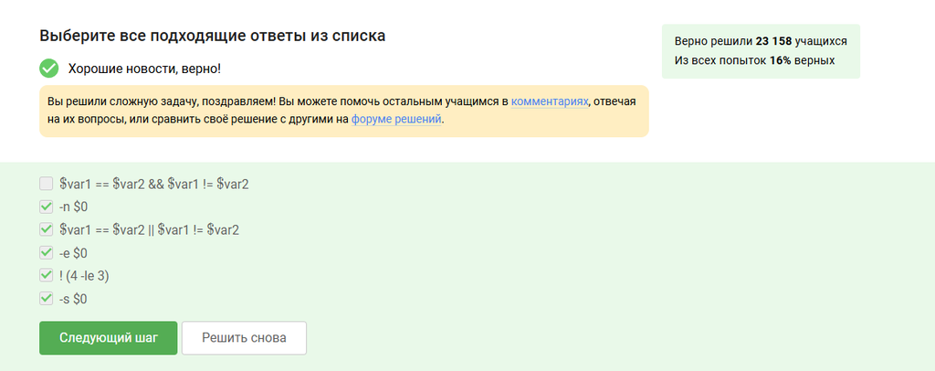

## Скриншот 10

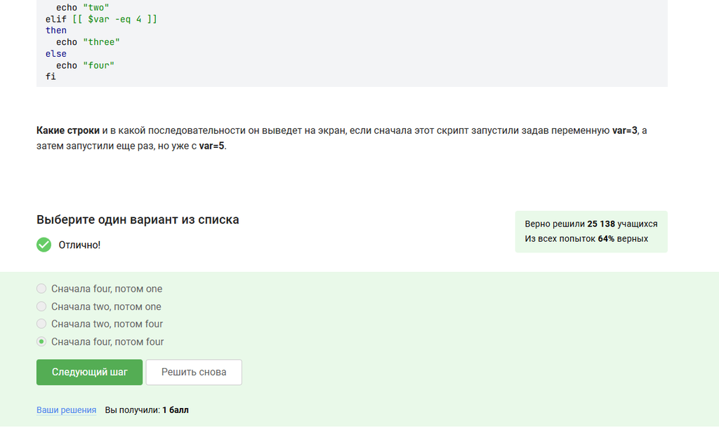

## Скриншот 11

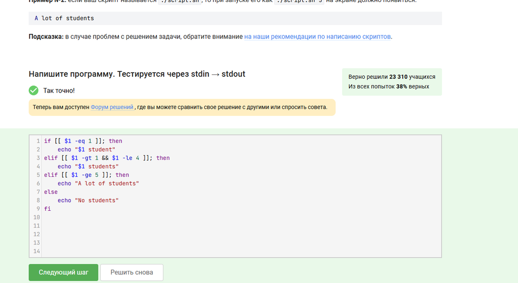

Выбрал вариант с выводом количества студентов в зависимости от ввода, исправив синтаксические ошибки в условиях (например, -qt на -gt).

## Скриншот 12

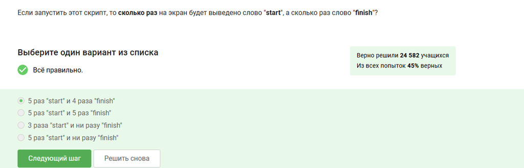

## Скриншот 13

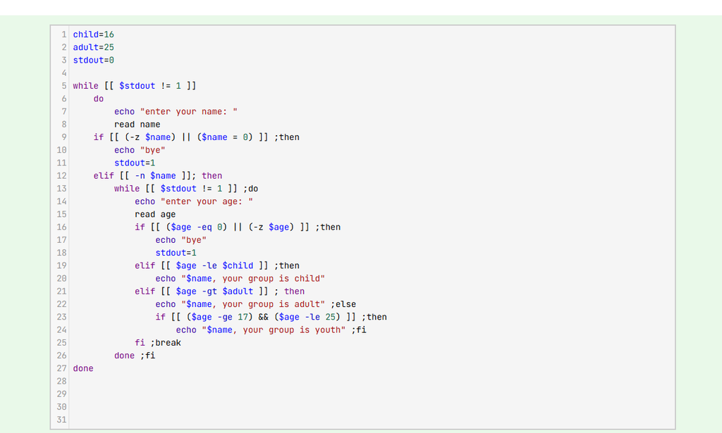

Скрипт корректно определяет возрастные группы (child, youth, adult) и завершается при вводе пустого значения или нуля.

## Скриншот 14

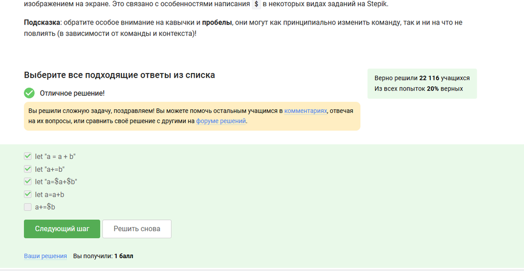

Выбраны варианты с корректным синтаксисом для операции let (например, let “a+=b” и let a=a+b).

## Скриншот 15

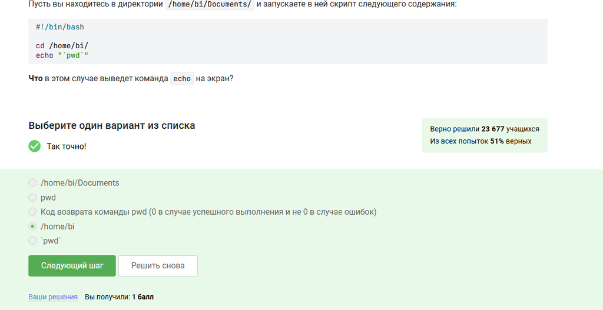

## Скриншот 16

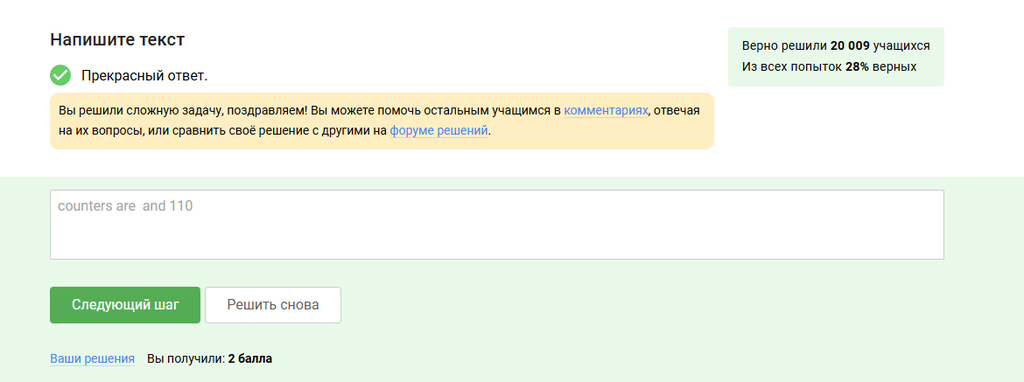

Решение задачи с подсчётом, вероятно, связано с исправлением ошибок в логике или синтаксисе скрипта.

## Скриншот 17

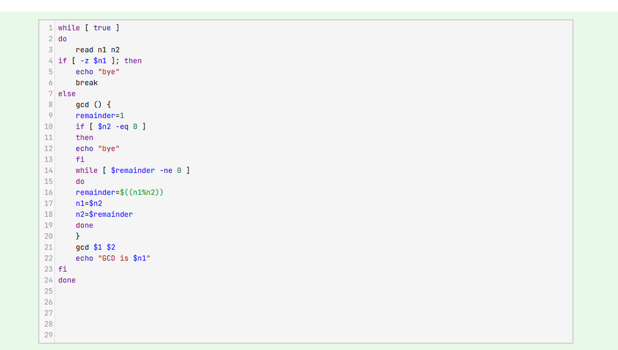

Исправлен алгоритм вычисления НОД (например, оператор % вместо $), чтобы он работал корректно.

## Скриншот 18

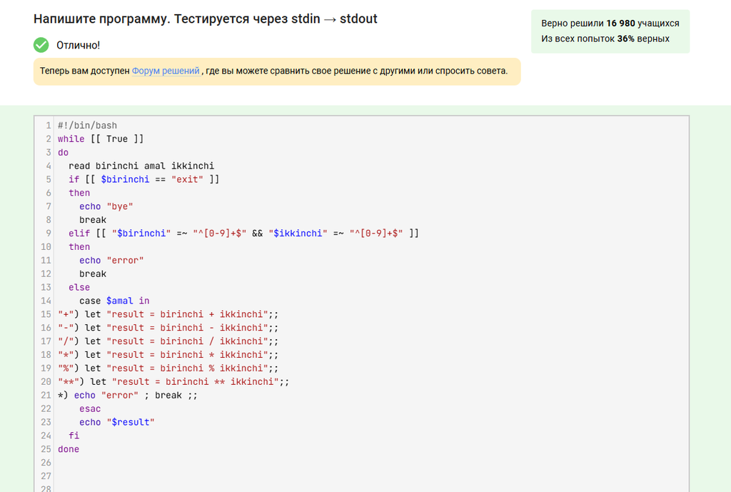

## Скриншот 19

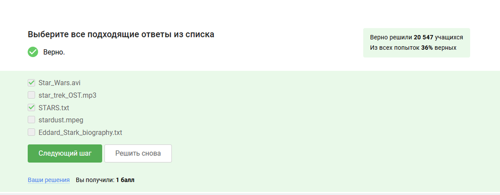

## Скриншот 20

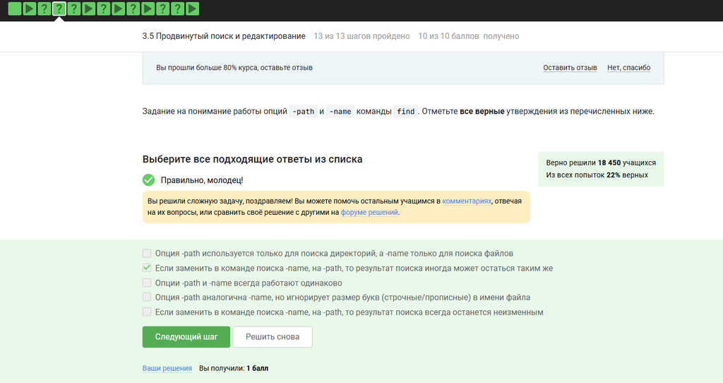

Верно отмечено, что -path и -name могут давать одинаковый результат в некоторых случаях, но не всегда.

## Скриншот 21

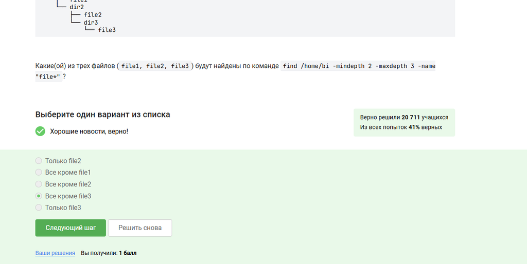

## Скриншот 22

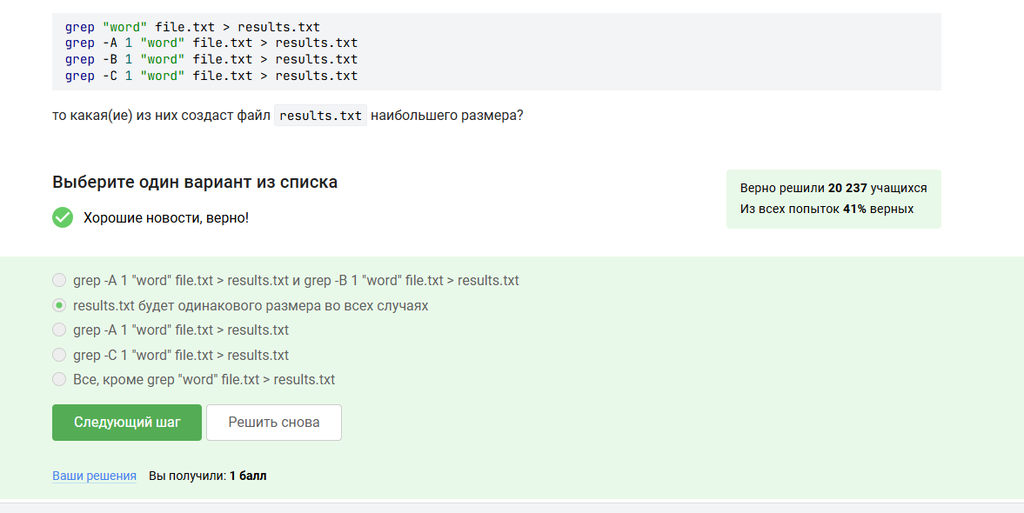

## Скриншот 23

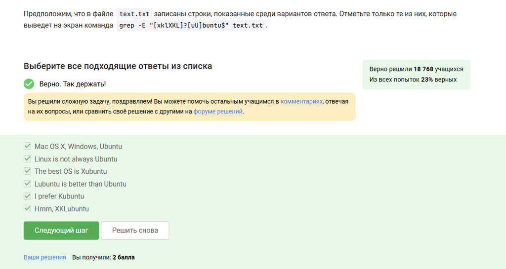

## Скриншот 24

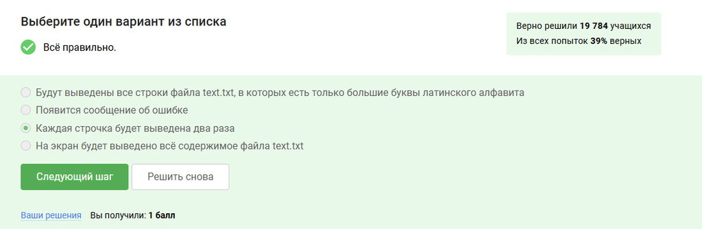

## Скриншот 25

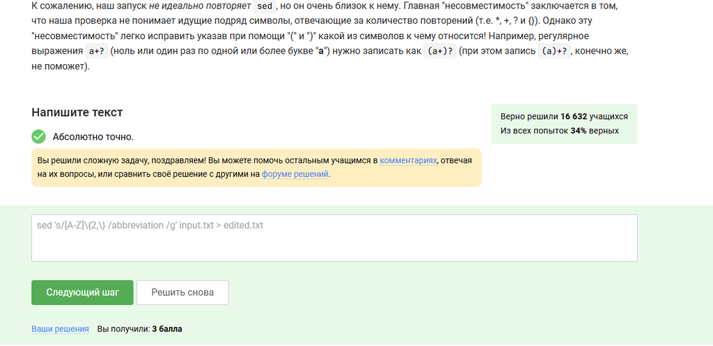

## Скриншот 26

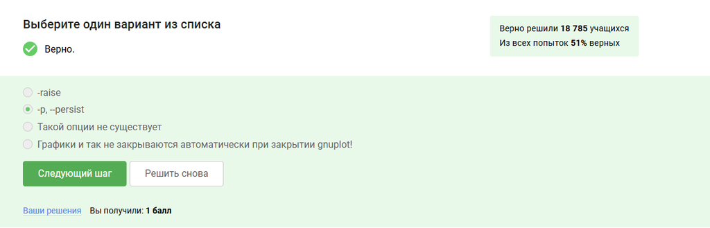

-p, –persist. Эта опция в gnuplot предотвращает автоматическое закрытие графиков после выполнения скрипта.

## Скриншот 27

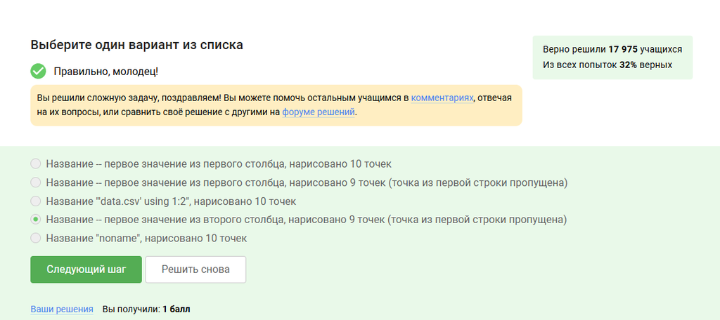

## Скриншот 28

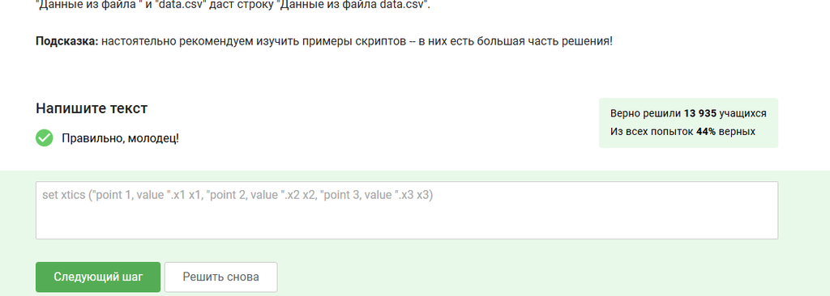

set xtics (“point 1, value”x1 x1, “point 2, value”x2 x2, “point 3, value”x3 x3”). Форматирование меток оси X.

## Скриншот 29

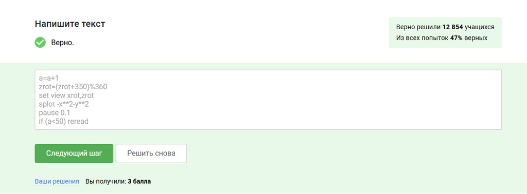

Скрипт создаёт анимацию вращения 3D-графика с помощью цикла reread.

## Скриншот 30

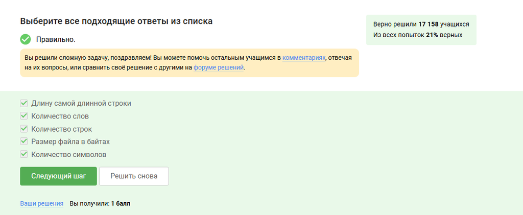

## Скриншот 31

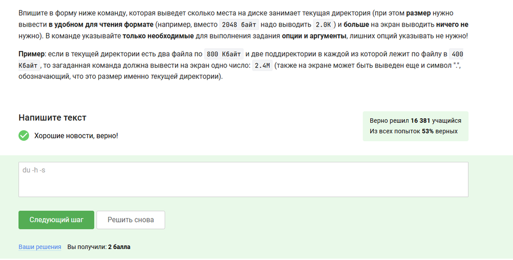

du -h -s. Команда выводит общий размер текущей директории в человекочитаемом формате.

## Скриншот 32

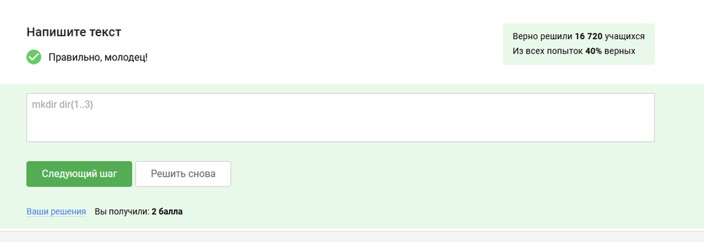

mkdir dir{1..3}. Команда создаёт три директории (dir1, dir2, dir3) за один раз.

## Выводы

Я прошёл и изучил третий раздел курса по Linux на платформе Stepik.  
Изучены: основы работы с редактором Vim, переменные и параметры shell, условия, циклы, регулярные выражения, find, grep, sed, а также основы построения графиков в gnuplot.